# ggplot2 practice

## bar & line graphs

### construct data frame

```r
df <- data.frame(time = factor(c("Lunch", "Dinner"), levels = c("Lunch","Dinner")), total_bill = c(14.89, 17.23))

library(ggplot2)
```

### basic graph

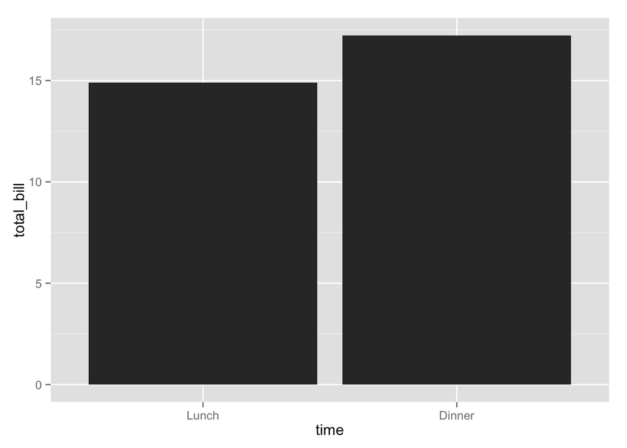

```r
ggplot(data=df,aes(x=time,y=total_bill)) + geom_bar(stat="identity")
```

ggplot instantiates a ggplot object, aes() specifies aesthetics, geom_bar is a **layer**, necessary to plot the object. specifies what to graph. stat = identity means values in the column of the data frame are plotted. stat = bin would bin them.

### fill colors

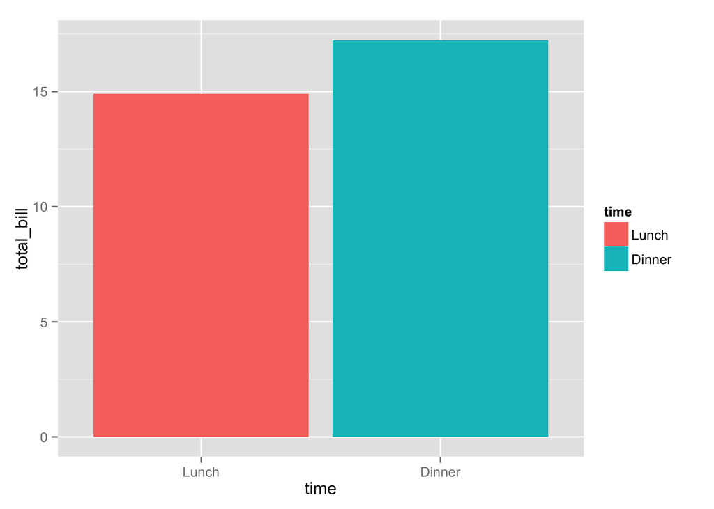

```r
ggplot(data=df,aes(x=time,y=total_bill, fill=time)) + geom_bar(stat="identity")
```

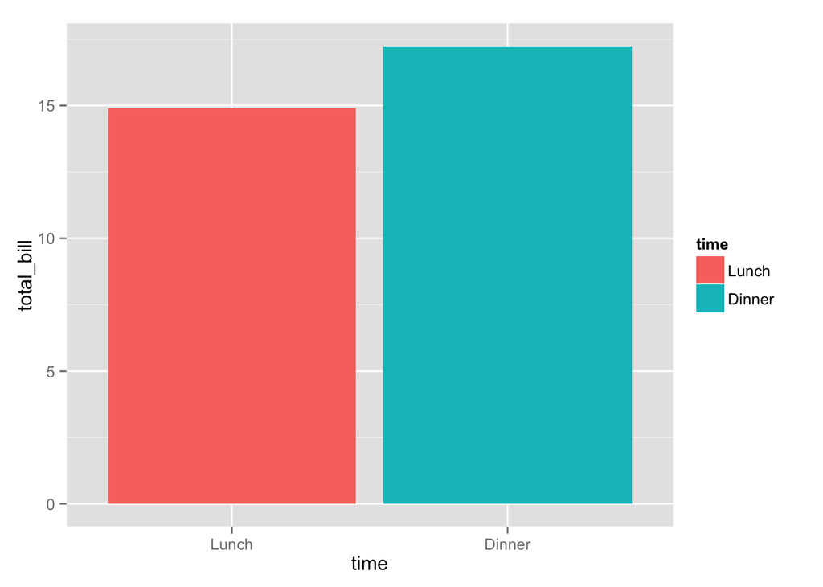

```r
# equivalently:
ggplot(data=df,aes(x=time,y=total_bill)) + geom_bar(aes(fill=time), stat="identity")
```

fill = the variable you want to color by.

### add outline and remove legend

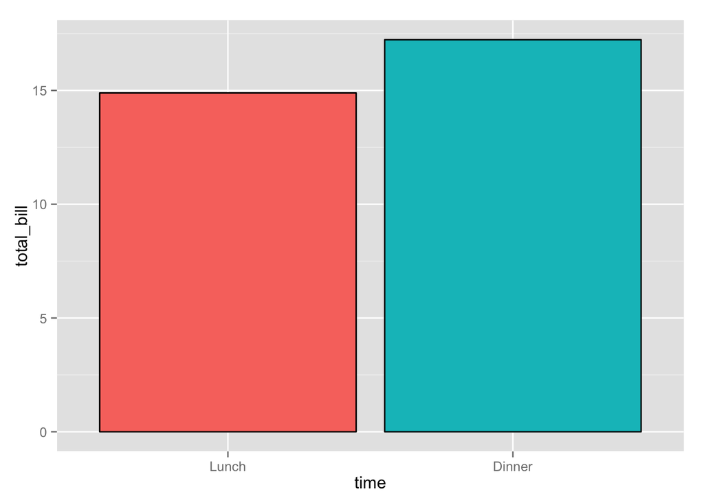

```r
ggplot(data=df,aes(x=time,y=total_bill, fill=time)) + geom_bar(color="black", stat="identity") + guides(fill=FALSE)
```

geom_bar’s color var allows you to set outline color. another ggplot attribute is guides, pertaining to legend (which I guess is implemented by default and you only need to specify it to remove.. or alter, presumably)

### fancify

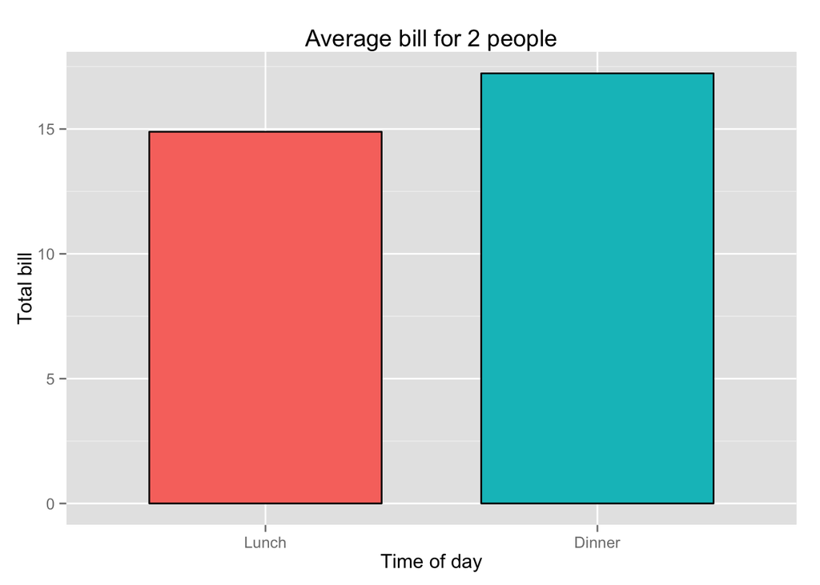

```r
ggplot(data=df, aes(x=time, y=total_bill, fill=time)) +
  geom_bar(color="black", fille="#DD8888", width=.7, stat="identity") +
  guides(fill=FALSE) +
  xlab("Time of day") + ylab("Total bill") +
  ggtitle("Average bill for 2 people")
```

neatly organized by category!

### now exploring binning

```r
library(reshape2)
head(tips)
```

```
##   total_bill  tip    sex smoker day   time size
## 1      16.99 1.01 Female     No Sun Dinner    2
## 2      10.34 1.66   Male     No Sun Dinner    3
## 3      21.01 3.50   Male     No Sun Dinner    3
## 4      23.68 3.31   Male     No Sun Dinner    2
## 5      24.59 3.61 Female     No Sun Dinner    4
## 6      25.29 4.71   Male     No Sun Dinner    4
```

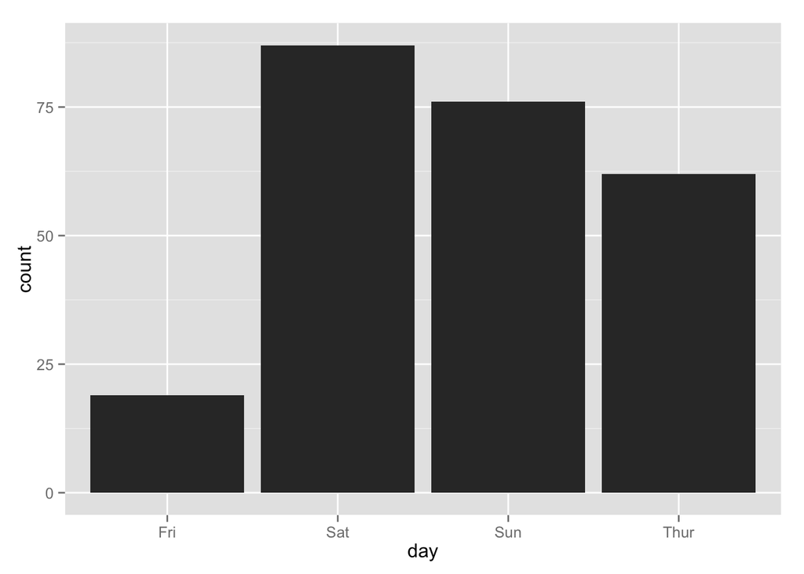

```r
ggplot(data=tips, aes(x=day)) + geom_bar()
```

stat=bin is the default, so you will get COUNTS of your x vars by default. all you need to specify is what your x axis should be

### line graphs

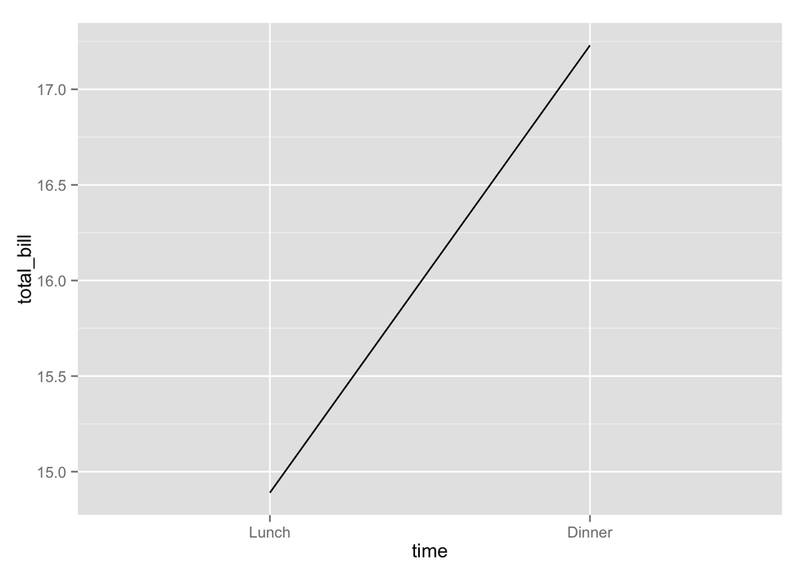

```r
ggplot(data=df, aes(x=time, y=total_bill, group=1)) + geom_line()
```

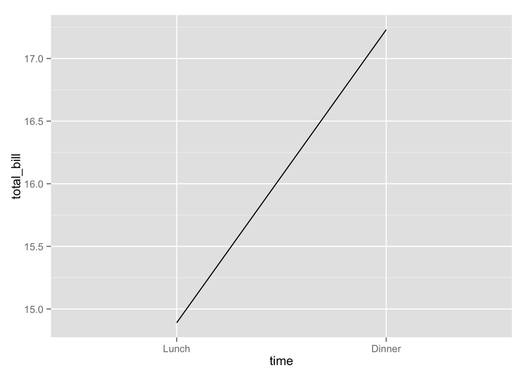

```r
#equivalently
ggplot(data=df, aes(x=time, y=total_bill)) + geom_line(aes(group=1))
```

group data so ggplot knows how to connect points. group=1 means all points connected. with more variables and lines, grouping usually done by variable. geom_line() used to specify line graph

### add points

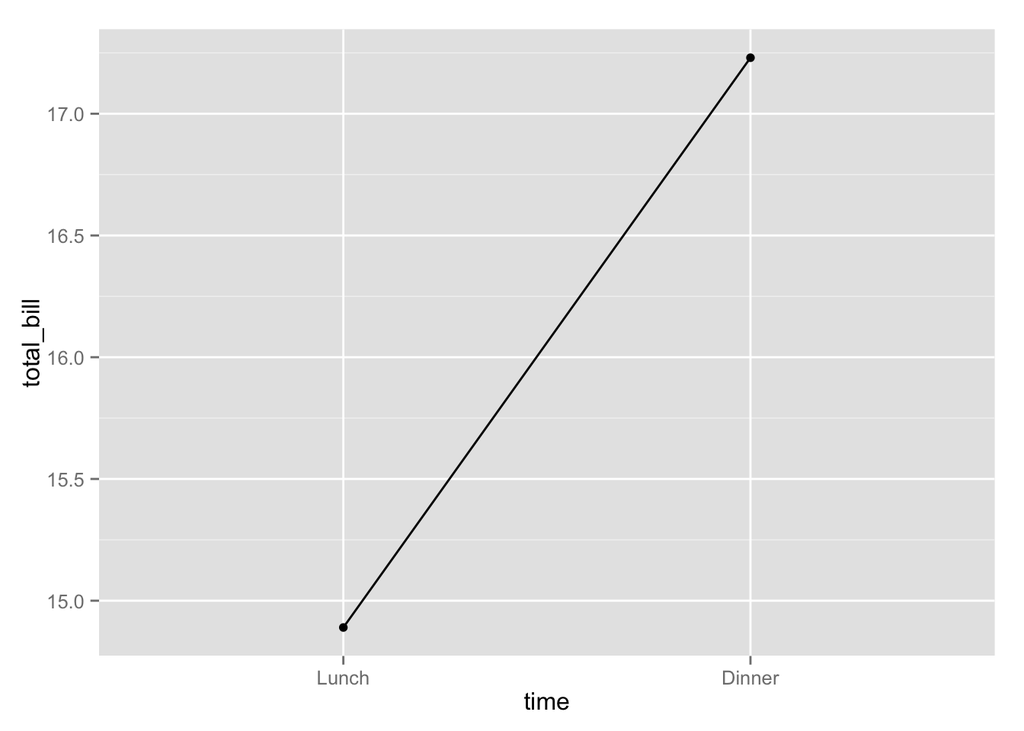

```r
ggplot(data=df, aes(x=time, y=total_bill, group=1)) + geom_line() + geom_point()
```

all that’s need is to add geom_point() attribute!

### fancify

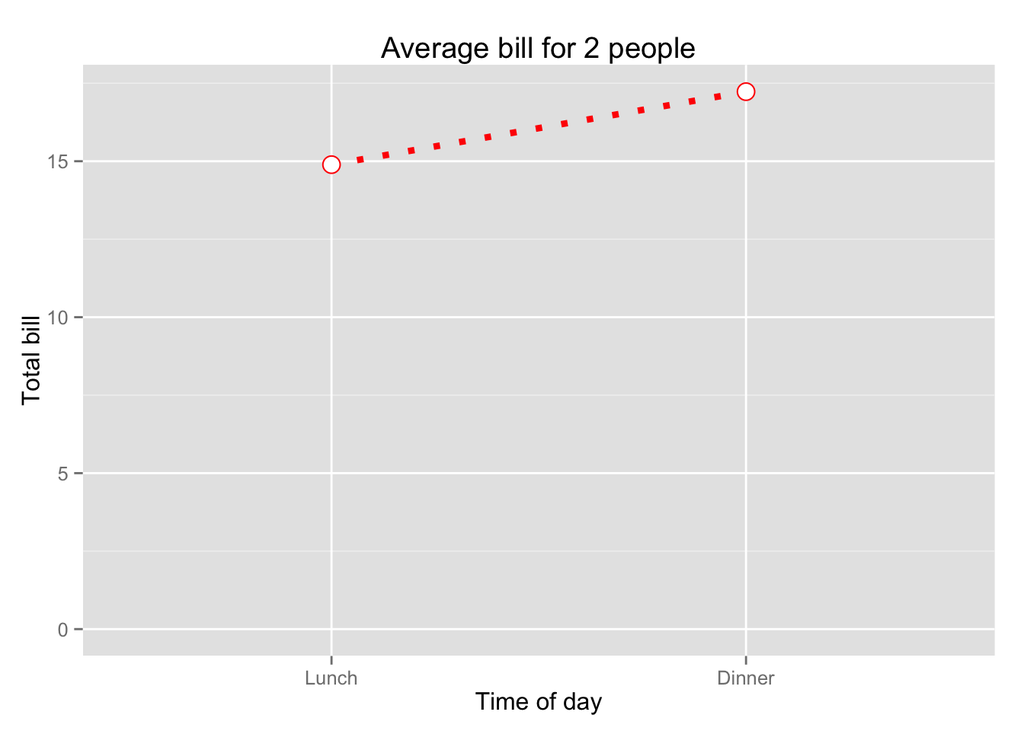

```r
ggplot(data=df, aes(x=time,y=total_bill, group=1)) +
  geom_line(color="red", linetype="dotted", size=1.5) +
  geom_point(color="red", size=4, shape=21, fill="white") +
  ylim(0, max(df$total_bill)) +
  xlab("Time of day") + ylab("Total bill") +
  ggtitle("Average bill for 2 people")
```

### multiple variables

```r
df1 <- data.frame(sex = factor(c("Female","Female","Male","Male")),
                  time = factor(c("Lunch","Dinner","Lunch","Dinner"), levels=c("Lunch","Dinner")),
                  total_bill = c(13.53, 16.81, 16.24, 17.42))
```

### bar graph

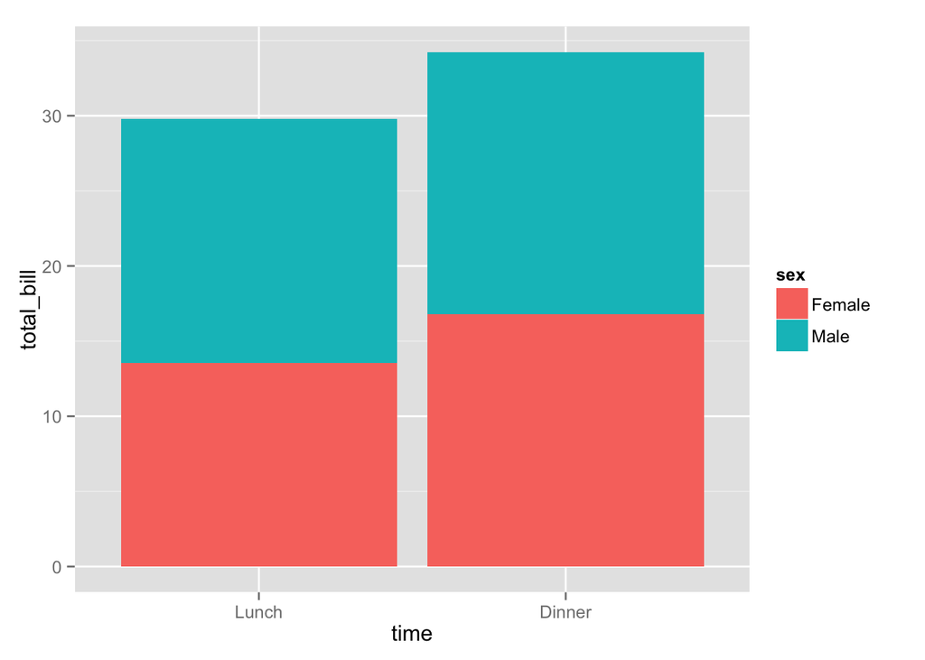

```r
ggplot(data=df1, aes(x=time, y=total_bill, fill=sex)) + geom_bar(stat="identity")
```

default is stacked

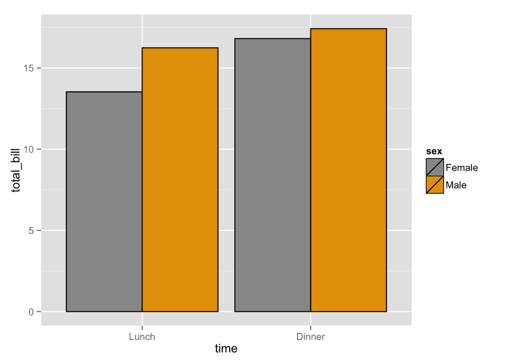

```r
ggplot(data=df1, aes(x=time, y=total_bill, fill=sex)) + geom_bar(stat="identity", position="dodge", color="black") + scale_fill_manual(values=c("#999999","#E69F00"))
```

position=position_dodge() (or position=“dodge”“) dodges overlaps to the side. can specify width and heigh here.

scale_fill_manual() allows you to specify values to use as colors (ordered).

### flip fill/axis mapping

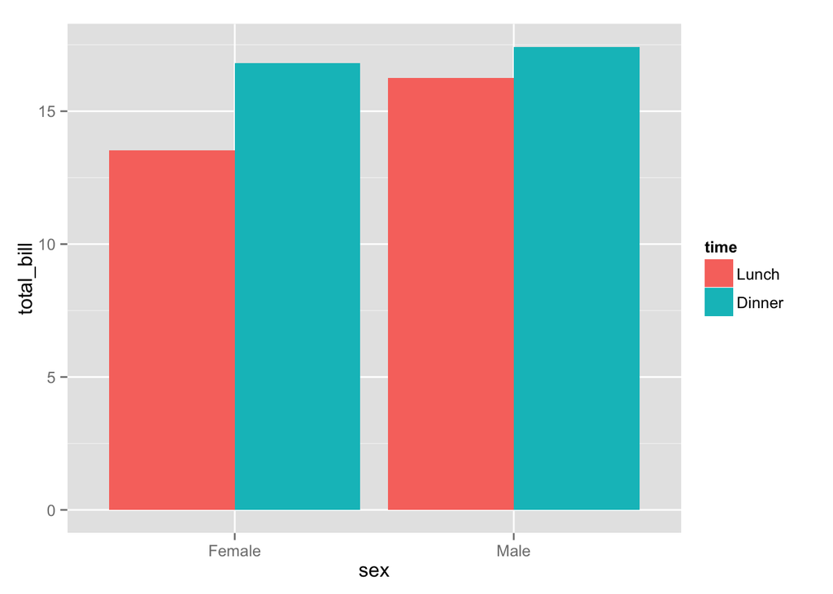

```r
ggplot(data=df1,aes(x=sex,y=total_bill,fill=time)) + geom_bar(stat="identity",position="dodge")
```

### line graphs

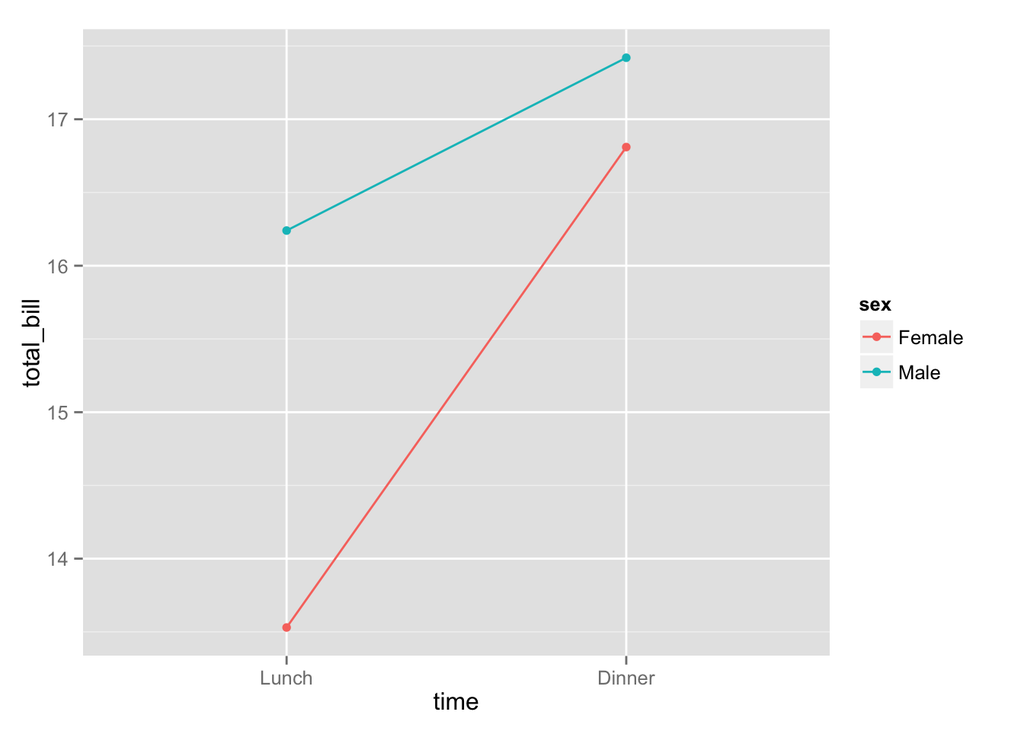

```r
ggplot(data=df1, aes(x=time, y=total_bill, group=sex, color=sex)) + geom_line() + geom_point()
```

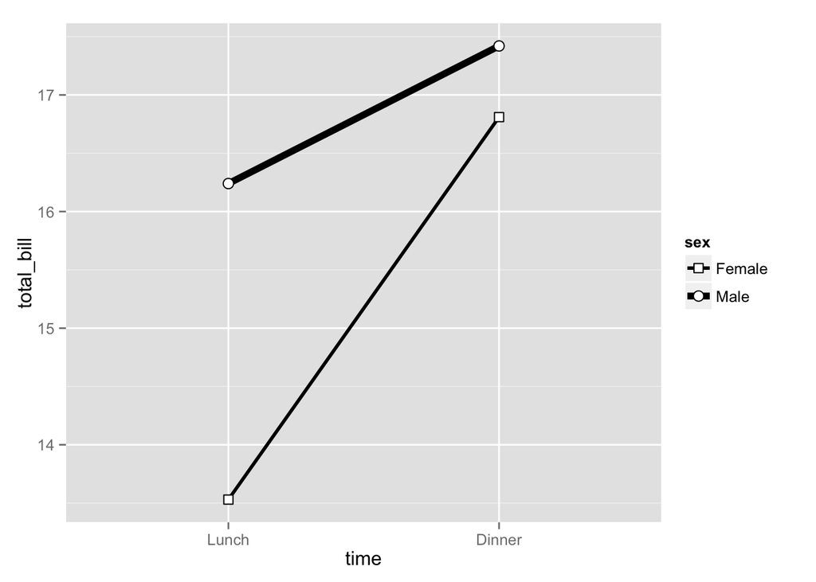

```r
ggplot(data=df1, aes(x=time, y=total_bill, group=sex, size=sex,shape=sex)) +
  geom_line() +
  geom_point(size=3, fill="white") +
  scale_shape_manual(values=c(22,21)) +
  scale_size_manual(values=c(1,2))
```

can use scale_blahblahblah_manual to group by a number of attributes – eg line thickness, point shape, color, probably dash style. easy peasy lemon squeezy

### setting legend titles

`scale_fill_hue(name="title")`

is a way to name legend titles. have to repeat for every scale() you add, so multiple legends are not created.

### graph themes

theme_gray The signature ggplot2 theme with a grey background and white gridlines, designed to put the data forward yet make comparisons easy.

theme_bw The classic dark-on-light ggplot2 theme. May work better for presentations displayed with a projector.

theme_linedraw A theme with only black lines of various widths on white backgrounds, reminiscent of a line drawings. Serves a purpose similar to theme_bw. Note that this theme has some very thin lines (<< 1 pt) which some journals may refuse.

theme_light A theme similar to theme_linedraw but with light grey lines and axes, to direct more attention towards the data.

theme_minimal A minimalistic theme with no background annotations.

theme_classic A classic-looking theme, with x and y axis lines and no gridlines.